# F9_00_ORG_PHONE

Organization phone · Identifier report

## Overview

**Description**

Filing Organization Telephone Number

**Table**

`F9-P00-T00-HEADER` (one)

**Location code**

`F990-PC-PART-00-SECTION-E`

**Family**

`F990-PC-PART-00-SECTION-E`

**Data type**

numeric (xsd: PhoneNumberType)

**Scope**

HD

**Status**

unreviewed

3

xpaths mapped (3 observed)

5,192,488

filings with a value

2009–2024

tax years observed

1

open flags (0 errors)

## Flags

[output not shown]

## Xpaths

All mapped xpaths (under /Return/ReturnData or /Return/ReturnHeader), oldest first. Charts label each series by its xpath.

| Xpath | Form | First year | Last year | Versions | Filings | Repeats in |
| --- | --- | --- | --- | --- | --- | --- |
| Filer/Phone | Header | 2009 | 2012 | 18 | 668,286 | 0.0% |
| Filer/PhoneNum | Header | 2013 | 2024 | 37 | 4,473,467 | 0.0% |
| Filer/ForeignPhoneNum | Header | 2020 | 2024 | 16 | 50,735 | 0.0% |

## Coverage

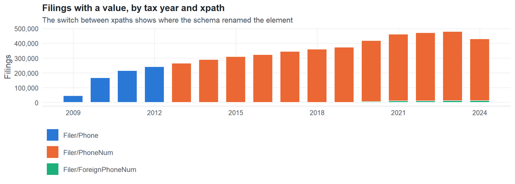

**Table view**

Table view: filings by tax year and series

| Tax year | Filer/Phone | Filer/PhoneNum | Filer/ForeignPhoneNum |
| --- | --- | --- | --- |
| 2009 | 45,587 | 0 | 0 |
| 2010 | 166,541 | 0 | 0 |
| 2011 | 215,100 | 0 | 0 |
| 2012 | 241,058 | 0 | 0 |
| 2013 | 0 | 264,482 | 0 |
| 2014 | 0 | 289,934 | 0 |
| 2015 | 0 | 309,403 | 0 |
| 2016 | 0 | 322,645 | 0 |
| 2017 | 0 | 344,833 | 0 |
| 2018 | 0 | 360,123 | 0 |
| 2019 | 0 | 373,300 | 0 |
| 2020 | 0 | 412,572 | 5,114 |
| 2021 | 0 | 451,847 | 9,993 |
| 2022 | 0 | 459,309 | 11,348 |
| 2023 | 0 | 467,020 | 12,357 |
| 2024 | 0 | 417,999 | 11,923 |

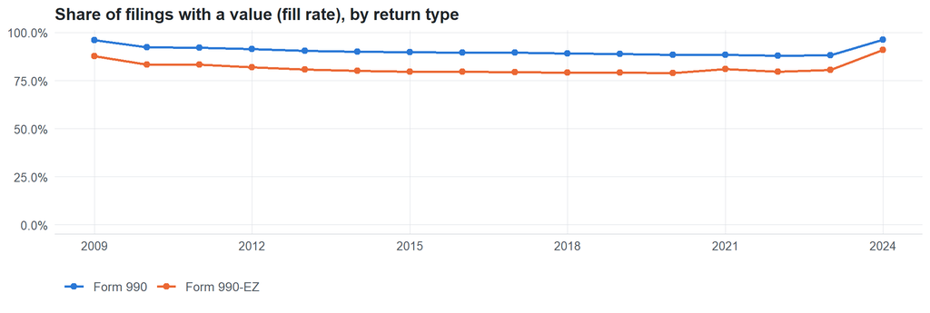

**Table view**

Table view: fill rate

| Tax year | Return type | Filings | All filings | Fill rate |
| --- | --- | --- | --- | --- |
| 2009 | Form 990 | 32,001 | 33,311 | 96.07% |
| 2009 | Form 990-EZ | 13,586 | 15,470 | 87.82% |
| 2010 | Form 990 | 113,700 | 123,025 | 92.42% |
| 2010 | Form 990-EZ | 52,841 | 63,326 | 83.44% |
| 2011 | Form 990 | 146,763 | 159,504 | 92.01% |
| 2011 | Form 990-EZ | 68,337 | 82,048 | 83.29% |
| 2012 | Form 990 | 164,169 | 179,688 | 91.36% |
| 2012 | Form 990-EZ | 76,889 | 93,750 | 82.01% |
| 2013 | Form 990 | 180,059 | 198,855 | 90.55% |
| 2013 | Form 990-EZ | 84,423 | 104,375 | 80.88% |
| 2014 | Form 990 | 196,735 | 218,619 | 89.99% |
| 2014 | Form 990-EZ | 93,199 | 116,417 | 80.06% |
| 2015 | Form 990 | 209,819 | 233,519 | 89.85% |
| 2015 | Form 990-EZ | 99,584 | 124,894 | 79.73% |
| 2016 | Form 990 | 218,686 | 243,903 | 89.66% |
| 2016 | Form 990-EZ | 103,959 | 130,484 | 79.67% |
| 2017 | Form 990 | 234,270 | 261,612 | 89.55% |
| 2017 | Form 990-EZ | 110,562 | 139,144 | 79.46% |
| 2018 | Form 990 | 241,778 | 271,442 | 89.07% |
| 2018 | Form 990-EZ | 118,345 | 149,384 | 79.22% |
| 2019 | Form 990 | 252,487 | 283,694 | 89.00% |
| 2019 | Form 990-EZ | 120,813 | 152,622 | 79.16% |
| 2020 | Form 990 | 283,486 | 320,342 | 88.49% |
| 2020 | Form 990-EZ | 134,198 | 169,864 | 79.00% |
| 2021 | Form 990 | 297,573 | 336,480 | 88.44% |
| 2021 | Form 990-EZ | 164,254 | 202,724 | 81.02% |
| 2022 | Form 990 | 306,683 | 349,055 | 87.86% |
| 2022 | Form 990-EZ | 163,962 | 206,130 | 79.54% |
| 2023 | Form 990 | 312,978 | 354,768 | 88.22% |
| 2023 | Form 990-EZ | 166,390 | 206,379 | 80.62% |
| 2024 | Form 990 | 267,143 | 277,298 | 96.34% |
| 2024 | Form 990-EZ | 162,774 | 178,867 | 91.00% |

## Values

| Result | Check | Detail |
| --- | --- | --- |
| ✓ pass | Values have the Phone format | 100.0% of values match ^9999999999$ |
| ⚠ fail | Stored as text | data type is numeric: leading zeros and letters would be lost |
| ▲ warn | No placeholder values | 8,214 filings use a placeholder such as 000000000 |
| ⓘ info | Leading zeros present | at least 1% of values start with 0 in some year, so numeric storage would change them |

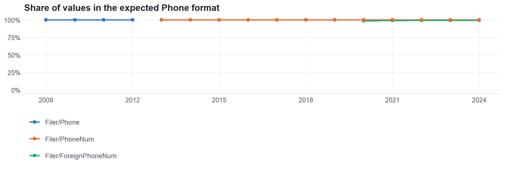

Value shapes (9 = digit, A = letter)

| Series | Shape | Expected | Filings |
| --- | --- | --- | --- |
| Filer/Phone | 9999999999 | yes | 668,286 |
| Filer/PhoneNum | 9999999999 | yes | 4,473,467 |
| Filer/ForeignPhoneNum | 9999999999 | yes | 50,387 |
| Filer/ForeignPhoneNum | 99999999999 | no | 175 |
| Filer/ForeignPhoneNum | 999999999 | no | 63 |
| Filer/ForeignPhoneNum | 999999999999 | no | 50 |
| Filer/ForeignPhoneNum | 9999999 | no | 37 |

## Examples

| Tax year | Return | Xpath | Organization | Value | Source |
| --- | --- | --- | --- | --- | --- |
| 2024 | 990EZ | Filer/ForeignPhoneNum | Science & Technology Education Project | 3366090479 | [XML](https://gt990datalake-rawdata.s3.amazonaws.com/EfileData/XmlFiles/202531709349200103_public.xml) |
| 2024 | 990EZ | Filer/PhoneNum | THE CREATIVES PROJECT INC | 4048294229 | [XML](https://gt990datalake-rawdata.s3.amazonaws.com/EfileData/XmlFiles/202510859349201521_public.xml) |
| 2023 | 990EZ | Filer/ForeignPhoneNum | GALBRAITH GRAVITY JUNIOR RACING | 3603068459 | [XML](https://gt990datalake-rawdata.s3.amazonaws.com/EfileData/XmlFiles/202422849349200002_public.xml) |
| 2023 | 990 | Filer/PhoneNum | ZEPF CENTER | 4198417701 | [XML](https://gt990datalake-rawdata.s3.amazonaws.com/EfileData/XmlFiles/202423399349300887_public.xml) |
| 2022 | 990EZ | Filer/ForeignPhoneNum | Most Worshipful Mount Carmel Grand Lodge | 5129170654 | [XML](https://gt990datalake-rawdata.s3.amazonaws.com/EfileData/XmlFiles/202340679349200009_public.xml) |
| 2022 | 990EZ | Filer/PhoneNum | Dana Point Post 9934 Veterans of Foreign Wars | 9492481419 | [XML](https://gt990datalake-rawdata.s3.amazonaws.com/EfileData/XmlFiles/202342379349201129_public.xml) |
| 2021 | 990EZ | Filer/ForeignPhoneNum | AMERICAN FEDERATION OF TEACHERS Local 3579 | 6108614142 | [XML](https://gt990datalake-rawdata.s3.amazonaws.com/EfileData/XmlFiles/202202909349200105_public.xml) |
| 2021 | 990EZ | Filer/PhoneNum | BLAINE 1 INC | 4063572244 | [XML](https://gt990datalake-rawdata.s3.amazonaws.com/EfileData/XmlFiles/202201369349200340_public.xml) |
| 2020 | 990EZ | Filer/ForeignPhoneNum | ONBOARD INC | 4045505947 | [XML](https://gt990datalake-rawdata.s3.amazonaws.com/EfileData/XmlFiles/202120989349200202_public.xml) |
| 2020 | 990 | Filer/PhoneNum | SOCIAL JUSTICE PUBLIC CHARTER SCHOOL | 2029685380 | [XML](https://gt990datalake-rawdata.s3.amazonaws.com/EfileData/XmlFiles/202201309349304660_public.xml) |
| 2019 | 990EZ | Filer/PhoneNum | CRESSKILL COUGARS UNITED SOCCER | 2015887062 | [XML](https://gt990datalake-rawdata.s3.amazonaws.com/EfileData/XmlFiles/202013089349200306_public.xml) |
| 2018 | 990 | Filer/PhoneNum | FORT PAYNE CHAMBER OF COMMERCE | 2568452741 | [XML](https://gt990datalake-rawdata.s3.amazonaws.com/EfileData/XmlFiles/201931359349306873_public.xml) |

## Reviewer checklist

- The definition matches the form line and instructions for every xpath’s schema years.
- Every xpath pooled here measures the same thing on the 990 and 990-EZ (close enough for analysis).
- The coverage chart has no unexplained gaps or jumps between tax years.
- Each open flag is fixed, or accepted with a note in validation_log.csv.
- The data type is text so leading zeros and letters survive.
- The identifier belongs to the entity the variable names (the filer, preparer, related organization…).
- Formats with and without punctuation (e.g. ZIP+4, dashes) are normalized consistently downstream.

Record the review as a row in `inst/extdata/src/validation_log.csv` (variable_name, reviewer, date, status, note). Evidence built 2026-09-23 17:09:04 MST from the ef2 DuckDB builds (tax years 2009–2024).